# Cumulative Post WS Survey Results 2022

Author - Arlin Cherian

Advisors - Donna Sedler, Nicholas Cheung

2022-07-29 (updated: 2022-10-04)

## Overview

This report contains visualizations of open-text survey questions from Post WS Survey questionnaire.

### Content-based questions:

#### Q1: Please describe any recommendations/comments for improvements to this Online Workshop Session?

Common topics related to recommendations on online workshop session

| Topics |
| --- |
| Need sample content to follow, especially on risk management. Need to break down content into slides with more explanation for new comers to PM. |
| Great real life scenarios shared by Bruce, would like more sample scenarios |
| Would love more examples or template projects using tools like asana or monday |
| Maybe have more discussions in breakout rooms about what tools are working for the audience |
| Overall well prepared and relevant examples but link to non-profit was unclear |
| Content on the slides easy to follow but would be nice to have a copy of it or PDF available |
| Need more time in the breakout room and for the activity as the rapport is slow in the beginning and most were unsure about how to proceed with the acitivity. Recommends better explanation of activity… |

#### Q2: The “Introduction to Project Management for Non-Profits” workshop is a high-level overview of project management. We are in the process of planning future topics for online workshops.

Common Future topics recommended by participants

| Topics |
| --- |
| More depth about project initiation, planning |
| Change management and project risk management |
| Project communication planning |
| Budget, financial planning (events, administrative costs) |
| Other PM tools like MS project, project libre etc |
| Return on Investment analysis, or analysis of past projects |
| business writing and leadership |
| Difference between non-profit PM vs. regular PM |

#### Q3: Recommendations for improvement when using SLACK to connect participants with each other and PMV Facilitators during this session?

Common slack recommendations and comments

| Topics |
| --- |
| Slack and emails are good/fine tools of communication |
| maybe do an exercise that involves slack communication to learn how to use it effectively |
| Invited to many slack channels so hard to keep up |
| slack is fine butfor zoom maybe create a process to encourage dialogue/conversation in the chat |
| post documents, handout any pre-reading to better prepare for the workshops |

#### Q4: Additional comments relating to the Facilitator(s)?

Common topics related to comments about facilitators

| Topics |
| --- |
| Great examples shared by Bruce, more examples and project sharing would help |
| Facilitator was very knowledgable, appreaciate the practice tricks and tips |
| Current facilitators are great, interest in inviting other facilitators to share/lead sections of learning to hear from other voices and experiences in the room |

#### Q5: We are also in the process of planning shorter, Advanced Workshop sessions. Which of the topics listed below would encourage you to register for future workshops with PMV?

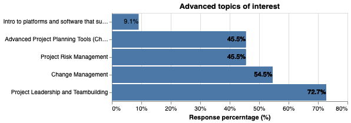

#### Q6: Would you prefer to attend online or in-person workshops with PMV? You are welcome to share comments in the “other” box below.

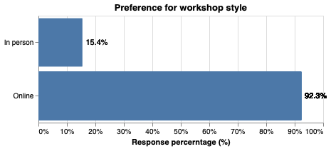

#### Q7: At the beginning of this Workshop, we invited you to join the Alumni Channel in SLACK to network with each other plus PM-Volunteers and other members in the NFP Community who attend PMV workshops….

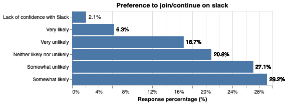

#### Q8: The Workshop content sustained my interest

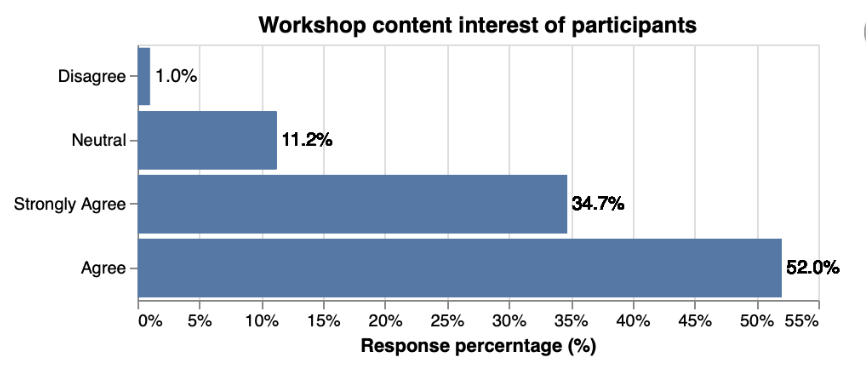

#### Q9: The Workshop content was easy to understand

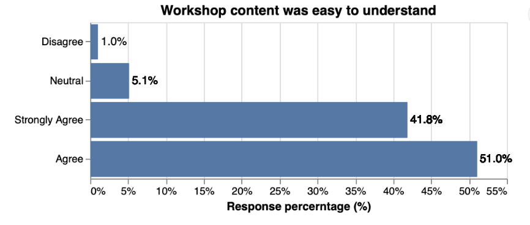

#### Q10: The Workshop content was relevant to my current job

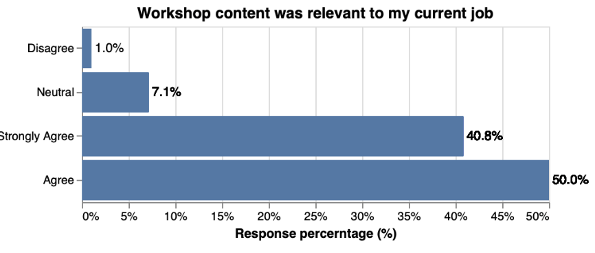

#### Q11: The Workshop content was relevant to my Organization

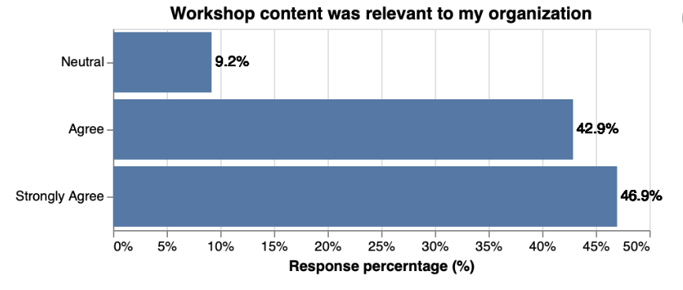

#### Q12: The optional and/or recommended practice exercises helped me understand the Workshop content

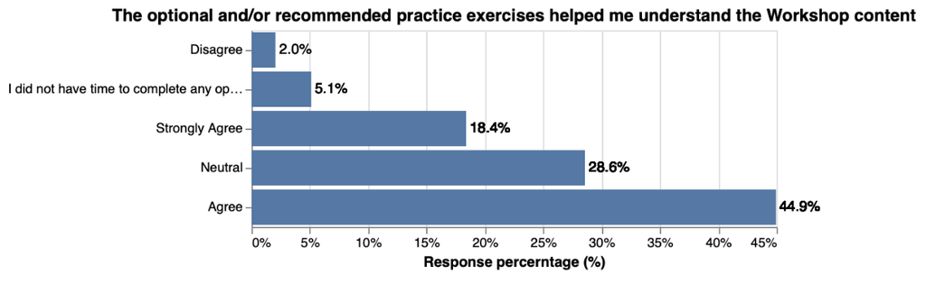

#### Q13: I will be able to apply the knowledge received from these Workshop sessions in my role or future projects

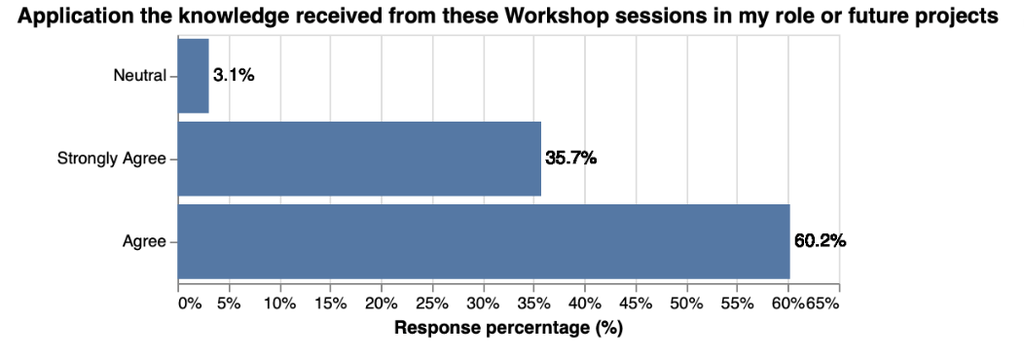

#### Q14: How would you rate the amount of content shared during these four 90 minute sessions?

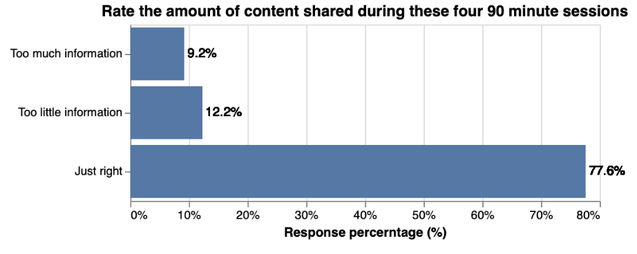

#### Q15: Facilitator was well prepared

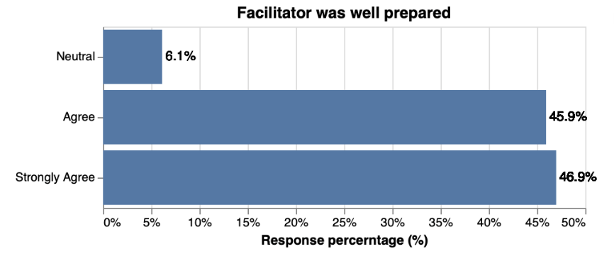

#### Q16: Facilitator was able to answer my questions

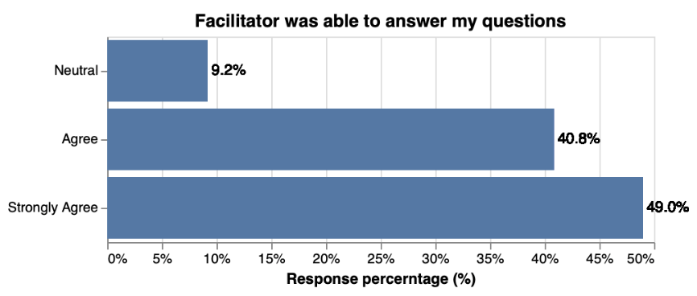

#### Q17: Facilitator provided real world experience

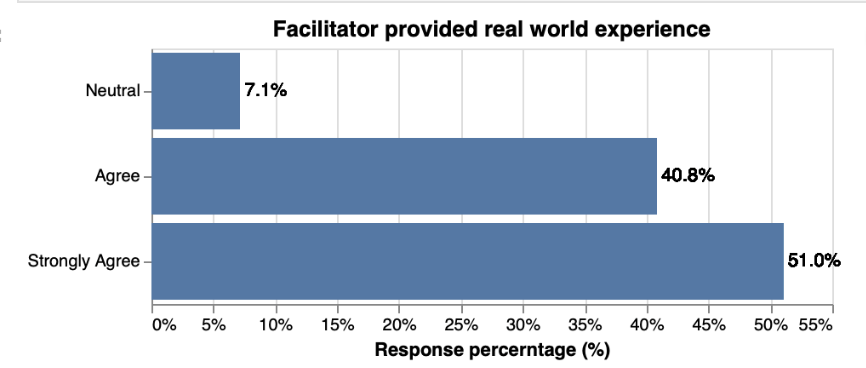

#### Q18: Facilitator possessed knowledge of the subject matter

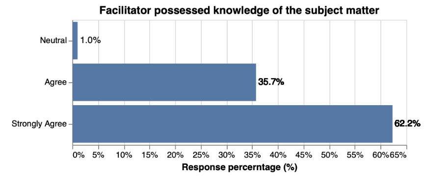

#### Q19: Facilitator was able to hold my attention¶

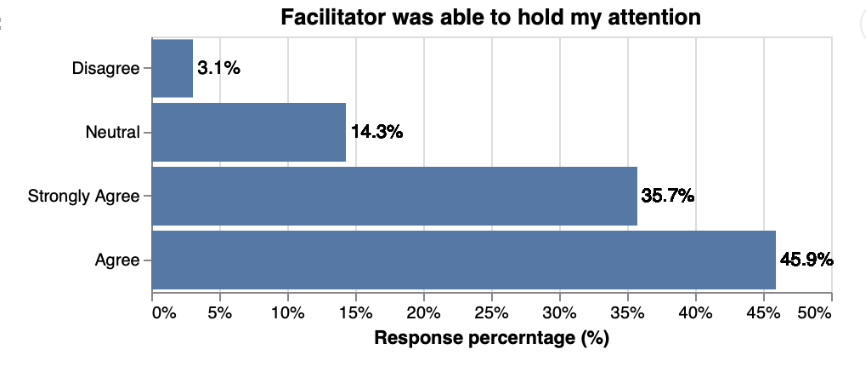